# Análise dos dados da wikipedia com intervalo de confiança

## Dados da wikipedia

O objeto principal da análise são as buscas e a navegação depois da busca.

Aqui, exploramos esses dados. Esses dados são derivadoes dos dados originais de eventos (event logging (EL)) capturados pela Wikimedia Foundation.

```r
library(tidyverse)
library(here)
library(lubridate)
library(resample)
library(boot)
theme_set(theme_bw())
```

```r
buscas = read_csv(here::here("data/search_data.csv"))
events = read_csv("https://github.com/wikimedia-research/Discovery-Hiring-Analyst-2016/raw/master/events_log.csv.gz")
events = events %>%
    group_by(session_id) %>%
    arrange(timestamp) %>%
    mutate(search_index = cumsum(action == "searchResultPage"), # contador de buscas na sessão.
           date = ymd_hms(timestamp))  %>%
    ungroup()
```

Essa analise busca responder as quetões originais do desafio criado pela wikimedia. Primeiramente busco responde as duas perguntas que são relacionadas que são:

## What is our daily overall clickthrough rate? How does it vary between the groups?

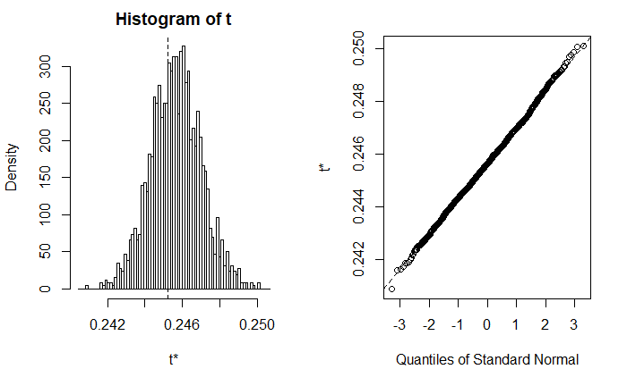

```r
set.seed(1234)
funcao_bootstrap <- function(dado, indices) {
  TotalPorHora <- dado %>%
    slice(indices) %>%
    mutate(session_start_date = round_date(session_start_date, unit = "hour")) %>%
    group_by(session_start_date) %>%
    summarise(count=n())%>%
    pull(count)
  clickRateHora <- dado %>%
    filter(num_clicks > 0) %>%
    slice(indices) %>%
    mutate(session_start_date = round_date(session_start_date, unit = "hour")) %>%
    group_by(session_start_date) %>%
    summarise(count=n())%>%
    pull(count)

  resultado = clickRateHora / TotalPorHora

  return(mean(resultado))
}
bootstraps <- boot(data = buscas,
                 statistic = funcao_bootstrap,
                 R = 2000)
plot(bootstraps)
```

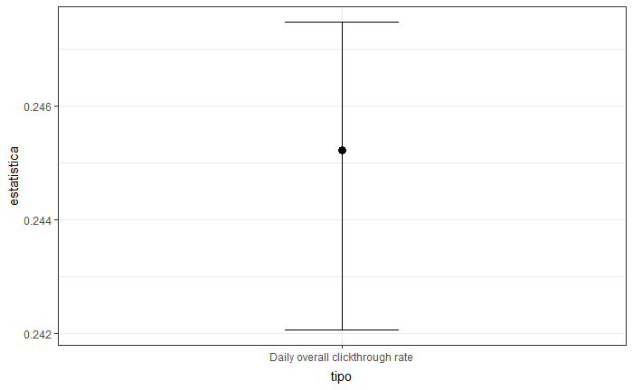

```r
boot_basic <- boot.ci(boot.out = bootstraps, conf = 0.95, type = "basic")
dados <- tibble(estatistica = as.double(boot_basic$t0),mini = as.double(boot_basic$basic[4]), maxi = as.double(boot_basic$basic[5]), tipo="Daily overall clickthrough rate")
ggplot(dados, aes(y=estatistica, x=tipo)) +
  geom_point(size=3) +
  geom_errorbar(aes(ymax=maxi, ymin=mini), width=0.2)
```

```r
boot_basic
```

```
BOOTSTRAP CONFIDENCE INTERVAL CALCULATIONS
Based on 2000 bootstrap replicates

CALL :
boot.ci(boot.out = bootstraps, conf = 0.95, type = "basic")

Intervals :
Level      Basic
95%   ( 0.2421,  0.2475 )
Calculations and Intervals on Original Scale
```

# Comparando entre os grupos

```r
funcao_bootstrap <- function(dado, indices) {
  TotalPorHoraA <- dado %>%
    slice(indices) %>%
    mutate(session_start_date = round_date(session_start_date, unit = "hour")) %>%
    filter( group == 'a')%>%
    group_by(session_start_date) %>%
    summarise(count=n())%>%
    pull(count)
  clickRateHoraA <- dado %>%
    filter(num_clicks > 0) %>%
    slice(indices) %>%
    mutate(session_start_date = round_date(session_start_date, unit = "hour")) %>%
    filter( group == 'a')%>%
    group_by(session_start_date) %>%
    summarise(count=n())%>%
    pull(count)

  resultadoA = clickRateHoraA / TotalPorHoraA

  TotalPorHoraB <- dado %>%
    slice(indices) %>%
    mutate(session_start_date = round_date(session_start_date, unit = "hour")) %>%
    filter( group == 'b')%>%
    group_by(session_start_date) %>%
    summarise(count=n())%>%
    pull(count)
  clickRateHoraB <- dado %>%
    slice(indices) %>%
    filter(num_clicks > 0) %>%
    mutate(session_start_date = round_date(session_start_date, unit = "hour")) %>%
    filter( group == 'b')%>%
    group_by(session_start_date) %>%
    summarise(count=n())%>%
    pull(count)

  resultadoB = clickRateHoraB / TotalPorHoraB

  return(mean(resultadoA) - mean(resultadoB))
}
funcao_bootstrap_geral <- function(dado, indices) {
  TotalPorHora <- dado %>%
    slice(indices) %>%
    mutate(session_start_date = round_date(session_start_date, unit = "hour")) %>%
    group_by(session_start_date) %>%
    summarise(count=n())%>%
    pull(count)
  clickRateHora <- dado %>%
    filter(num_clicks > 0) %>%
    slice(indices) %>%
    mutate(session_start_date = round_date(session_start_date, unit = "hour")) %>%
    group_by(session_start_date) %>%
    summarise(count=n())%>%
    pull(count)

  resultado = clickRateHora / TotalPorHora

  return(mean(resultado))
}
buscas_a <- buscas  %>% filter(group == 'a')
buscas_b <- buscas  %>% filter(group == 'b')
bootstraps <- boot(data = buscas,
                 statistic = funcao_bootstrap,
                 R = 2000)
```

[output not shown]

```r
bootstraps_a <- boot(data = buscas_a,
                 statistic = funcao_bootstrap_geral,
                 R = 2000)
bootstraps_b <- boot(data = buscas_b,
                 statistic = funcao_bootstrap_geral,
                 R = 2000)
```

[output not shown]

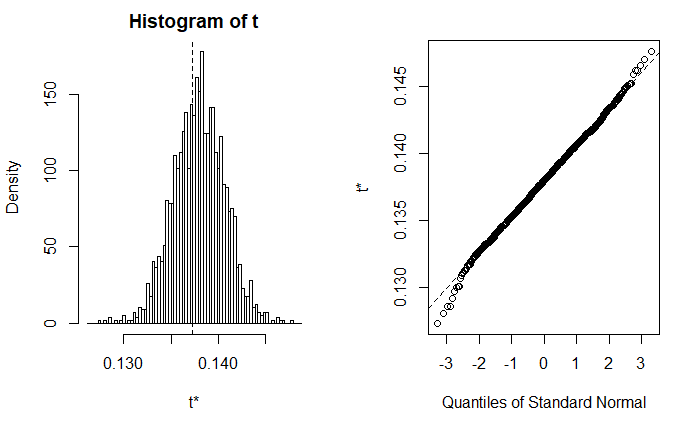

```r
plot(bootstraps)
```

[figure not shown]

```r
boot_basic <- boot.ci(boot.out = bootstraps, conf = 0.95, type = "basic")
boot_basic_a <- boot.ci(boot.out = bootstraps_a, conf = 0.95, type = "basic")
boot_basic_b <- boot.ci(boot.out = bootstraps_b, conf = 0.95, type = "basic")
dados <- tibble(estatistica = as.double(boot_basic$t0),mini = as.double(boot_basic$basic[4]), maxi = as.double(boot_basic$basic[5]), tipo="Diferença da média")
dados_a <- tibble(estatistica = as.double(boot_basic_a$t0),mini = as.double(boot_basic_a$basic[4]), maxi = as.double(boot_basic_a$basic[5]), tipo="A")
dados_b <- tibble(estatistica = as.double(boot_basic$t0),mini = as.double(boot_basic$basic[4]), maxi = as.double(boot_basic$basic[5]), tipo="B")
resultados <- bind_rows(dados_a, dados, dados_b)
ggplot(resultados, aes(y=estatistica, x=tipo)) +
  geom_point(size=3) +
  geom_errorbar(aes(ymax=maxi, ymin=mini), width=0.2)
```

```r
boot_basic
```

```
BOOTSTRAP CONFIDENCE INTERVAL CALCULATIONS
Based on 2000 bootstrap replicates

CALL :
boot.ci(boot.out = bootstraps, conf = 0.95, type = "basic")

Intervals :
Level      Basic
95%   ( 0.1313,  0.1418 )
Calculations and Intervals on Original Scale
```

## What is our daily overall zero results rate? How does it vary between the groups?

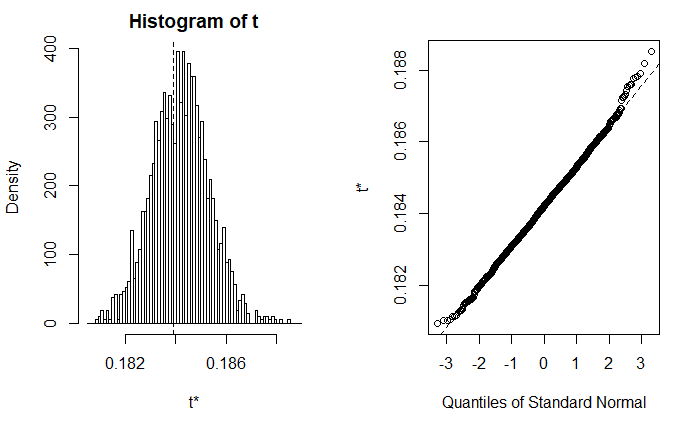

```r
funcao_bootstrap <- function(dado, indices) {
  TotalPorHora <- dado %>%
    slice(indices) %>%
    mutate(session_start_date = round_date(session_start_date, unit = "hour")) %>%
    group_by(session_start_date) %>%
    summarise(count=n())%>%
    pull(count)
  clickRateHora <- dado %>%
    filter(results == 0) %>%
    slice(indices) %>%
    mutate(session_start_date = round_date(session_start_date, unit = "hour")) %>%
    group_by(session_start_date) %>%
    summarise(count=n())%>%
    pull(count)

  resultado = clickRateHora / TotalPorHora

  return(mean(resultado))
}
bootstraps <- boot(data = buscas,
                 statistic = funcao_bootstrap,
                 R = 2000)
plot(bootstraps)
```

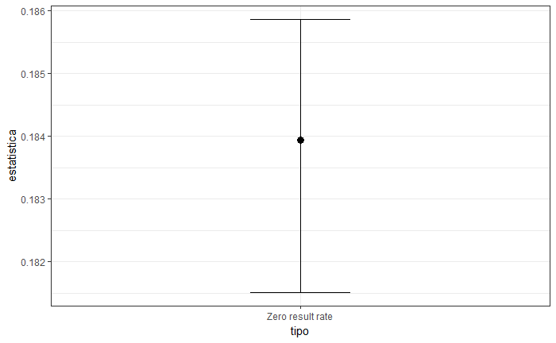

```r
boot_basic <- boot.ci(boot.out = bootstraps, conf = 0.95, type = "basic")
dados <- tibble(estatistica = as.double(boot_basic$t0),mini = as.double(boot_basic$basic[4]), maxi = as.double(boot_basic$basic[5]), tipo="Zero result rate")
ggplot(dados, aes(y=estatistica, x=tipo)) +
  geom_point(size=3) +
  geom_errorbar(aes(ymax=maxi, ymin=mini), width=0.2)
```

```r
boot_basic
```

```
BOOTSTRAP CONFIDENCE INTERVAL CALCULATIONS
Based on 2000 bootstrap replicates

CALL :
boot.ci(boot.out = bootstraps, conf = 0.95, type = "basic")

Intervals :
Level      Basic
95%   ( 0.1815,  0.1859 )
Calculations and Intervals on Original Scale
```

A taxa de zero resultados média encontrada na população com uma confiança de 95% está localizada no intervalo entre 18,15% e 18,59%.

# Comparando entre os grupos

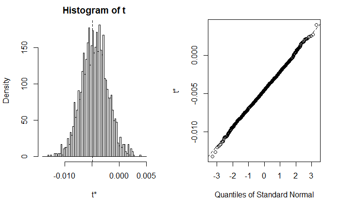

```r
funcao_bootstrap <- function(dado, indices) {
  TotalPorHoraA <- dado %>%
    slice(indices) %>%
    mutate(session_start_date = round_date(session_start_date, unit = "hour")) %>%
    filter( group == 'a')%>%
    group_by(session_start_date) %>%
    summarise(count=n())%>%
    pull(count)
  clickRateHoraA <- dado %>%
    filter(results == 0) %>%
    slice(indices) %>%
    mutate(session_start_date = round_date(session_start_date, unit = "hour")) %>%
    filter( group == 'a')%>%
    group_by(session_start_date) %>%
    summarise(count=n())%>%
    pull(count)

  resultadoA = clickRateHoraA / TotalPorHoraA

  TotalPorHoraB <- dado %>%
    slice(indices) %>%
    mutate(session_start_date = round_date(session_start_date, unit = "hour")) %>%
    filter( group == 'b')%>%
    group_by(session_start_date) %>%
    summarise(count=n())%>%
    pull(count)
  clickRateHoraB <- dado %>%
    slice(indices) %>%
    filter(results == 0) %>%
    mutate(session_start_date = round_date(session_start_date, unit = "hour")) %>%
    filter( group == 'b')%>%
    group_by(session_start_date) %>%
    summarise(count=n())%>%
    pull(count)

  resultadoB = clickRateHoraB / TotalPorHoraB

  return(mean(resultadoA) - mean(resultadoB))
}
funcao_bootstrap_geral <- function(dado, indices) {
  TotalPorHora <- dado %>%
    slice(indices) %>%
    mutate(session_start_date = round_date(session_start_date, unit = "hour")) %>%
    group_by(session_start_date) %>%
    summarise(count=n())%>%
    pull(count)
  clickRateHora <- dado %>%
    filter(results == 0) %>%
    slice(indices) %>%
    mutate(session_start_date = round_date(session_start_date, unit = "hour")) %>%
    group_by(session_start_date) %>%
    summarise(count=n())%>%
    pull(count)

  resultado = clickRateHora / TotalPorHora

  return(mean(resultado))
}
bootstraps <- boot(data = buscas,
                 statistic = funcao_bootstrap,
                 R = 2000)
bootstraps_a <- boot(data = buscas_a,
                 statistic = funcao_bootstrap_geral,
                 R = 2000)
bootstraps_b <- boot(data = buscas_b,
                 statistic = funcao_bootstrap_geral,
                 R = 2000)
plot(bootstraps)
```

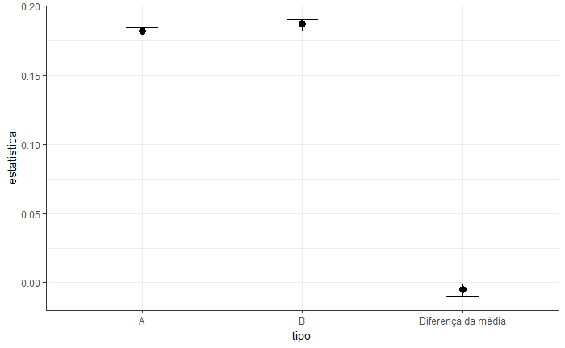

```r
boot_basic <- boot.ci(boot.out = bootstraps, conf = 0.95, type = "basic")
boot_basic_a <- boot.ci(boot.out = bootstraps_a, conf = 0.95, type = "basic")
boot_basic_b <- boot.ci(boot.out = bootstraps_b, conf = 0.95, type = "basic")
dados <- tibble(estatistica = as.double(boot_basic$t0),mini = as.double(boot_basic$basic[4]), maxi = as.double(boot_basic$basic[5]), tipo="Diferença da média")
dados_a <- tibble(estatistica = as.double(boot_basic_a$t0),mini = as.double(boot_basic_a$basic[4]), maxi = as.double(boot_basic_a$basic[5]), tipo="A")
dados_b <- tibble(estatistica = as.double(boot_basic_b$t0),mini = as.double(boot_basic_b$basic[4]), maxi = as.double(boot_basic_b$basic[5]), tipo="B")
resultados <- bind_rows(dados_a, dados, dados_b)
ggplot(resultados, aes(y=estatistica, x=tipo)) +
  geom_point(size=3) +
  geom_errorbar(aes(ymax=maxi, ymin=mini), width=0.2)
```

```r
boot_basic
```

```
BOOTSTRAP CONFIDENCE INTERVAL CALCULATIONS
Based on 2000 bootstrap replicates

CALL :
boot.ci(boot.out = bootstraps, conf = 0.95, type = "basic")

Intervals :
Level      Basic
95%   (-0.0103, -0.0006 )
Calculations and Intervals on Original Scale
```

Como podemos ver pelo resultado da comparação, o intervalo não passa pelo 0 o que significa que com uma confiança de 95% podemos afirmar que há uma diferença significativa entre o grupo A e o grupo B na população. Essa diferença está entre 1,03% e 0,06% onde o grupo B é maior que o grupo A.

## Testa o que acontece se para a pergunta 1, em vez de comparar o grupo A com o grupo B (um teste A/B), você compara metade das sessões do grupo A (escolhida aleatoriamente) com outra metade das sessões do mesmo grupo (um teste A/A).

```r
buscas_a <- buscas %>% filter(group == 'a')
smp_size <- floor(0.5 * nrow(buscas_a))
ind <- sample(seq_len(nrow(buscas_a)), size = smp_size)
train <- buscas_a[ind, ]%>%
  mutate(tipo = 1)
test <- buscas_a[-ind, ]%>%
  mutate(tipo = 2)
buscas_a <- bind_rows(test, train)
funcao_bootstrap <- function(dado, indices) {
  TotalPorHoraA <- dado %>%
    slice(indices) %>%
    mutate(session_start_date = round_date(session_start_date, unit = "hour")) %>%
    filter( tipo == 1)%>%
    group_by(session_start_date) %>%
    summarise(count=n())%>%
    pull(count)
  clickRateHoraA <- dado %>%
    filter(num_clicks > 0) %>%
    slice(indices) %>%
    mutate(session_start_date = round_date(session_start_date, unit = "hour")) %>%
    filter( tipo == 1)%>%
    group_by(session_start_date) %>%
    summarise(count=n())%>%
    pull(count)

  resultadoA = clickRateHoraA / TotalPorHoraA

  TotalPorHoraB <- dado %>%
    slice(indices) %>%
    mutate(session_start_date = round_date(session_start_date, unit = "hour")) %>%
    filter( tipo == 2)%>%
    group_by(session_start_date) %>%
    summarise(count=n())%>%
    pull(count)
  clickRateHoraB <- dado %>%
    slice(indices) %>%
    filter(num_clicks > 0) %>%
    mutate(session_start_date = round_date(session_start_date, unit = "hour")) %>%
    filter( tipo == 2)%>%
    group_by(session_start_date) %>%
    summarise(count=n())%>%
    pull(count)

  resultadoB = clickRateHoraB / TotalPorHoraB

  return(mean(resultadoA) - mean(resultadoB))
}
bootstraps <- boot(data = buscas_a,
                 statistic = funcao_bootstrap,
                 R = 2000)
summary(bootstraps$t)
```

```
       V1
 Min.   :-0.0104819
 1st Qu.:-0.0007059
 Median : 0.0017574
 Mean   : 0.0017825
 3rd Qu.: 0.0042675
 Max.   : 0.0148676
```

```r
boot.ci(boot.out = bootstraps, conf = 0.95, type = "basic")
```

```
BOOTSTRAP CONFIDENCE INTERVAL CALCULATIONS
Based on 2000 bootstrap replicates

CALL :
boot.ci(boot.out = bootstraps, conf = 0.95, type = "basic")

Intervals :
Level      Basic
95%   (-0.0085,  0.0058 )
Calculations and Intervals on Original Scale
```

Como esperado, podemos ver que o intervalo passa pelo zero, logo, com uma confiança de 95%, não podemos afirmar que existe uma diferença entre a média de clique entre os dois subconjuntos de A.

## Which results do people tend to try first? How does it change day-to-day?

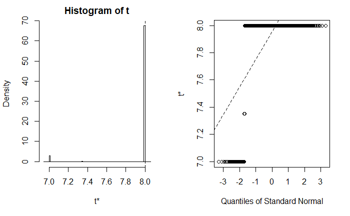

```r
buscas_interesse <- buscas%>%
    mutate(session_start_date = round_date(session_start_date, unit = "day")) %>%
    filter(!is.na(first_click) & first_click <= results)
primeiro_clique <- function(dados, indices) {
    resultado <- dados %>%
            slice(indices) %>%
            pull(first_click) %>%
            quantile(.95)

    return(resultado)
}
bootstraps <- boot(data = buscas_interesse,
                 statistic = primeiro_clique,
                 R = 2000)
plot(bootstraps)
```

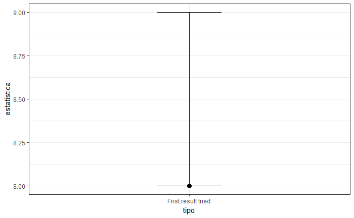

```r
boot_basic <- boot.ci(boot.out = bootstraps, conf = 0.95, type = "basic")
dados <- tibble(estatistica = as.double(boot_basic$t0),mini = as.double(boot_basic$basic[4]), maxi = as.double(boot_basic$basic[5]), tipo="First result tried")
ggplot(dados, aes(y=estatistica, x=tipo)) +
  geom_point(size=3) +
  geom_errorbar(aes(ymax=maxi, ymin=mini), width=0.2)
```

```r
boot_basic
```

```
BOOTSTRAP CONFIDENCE INTERVAL CALCULATIONS
Based on 2000 bootstrap replicates

CALL :
boot.ci(boot.out = bootstraps, conf = 0.95, type = "basic")

Intervals :
Level      Basic
95%   ( 8,  9 )
Calculations and Intervals on Original Scale
```

O valor de 95 percentil do valor de primeiro clique encontrado na população com uma confiança de 95% está localizado no intervalo entre 8 e 9.

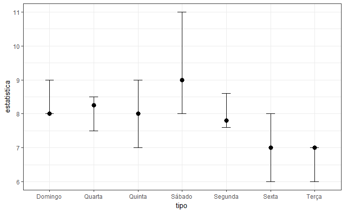

```r
buscas_interesse <- buscas_interesse %>%mutate(dia_da_semana = strftime(session_start_date, '%u'))
filtrar_por_dia <- function(dia, busca) {
    resultado <- busca %>%
                    filter(dia_da_semana == dia)
    return(resultado)
}
valores_domingo <- filtrar_por_dia(7, buscas_interesse)
valores_segunda <- filtrar_por_dia(1,buscas_interesse)
valores_terca <- filtrar_por_dia(2,buscas_interesse)
valores_quarta <- filtrar_por_dia(3, buscas_interesse)
valores_quinta <- filtrar_por_dia(4, buscas_interesse)
valores_sexta <- filtrar_por_dia(5, buscas_interesse)
valores_sabado <- filtrar_por_dia(6, buscas_interesse)
primeiro_clique <- function(dados, indices) {
    resultado <- dados %>%
            slice(indices) %>%
            pull(first_click) %>%
            quantile(.95)

    return(resultado)
}
bootstraps_1 <- boot(data = valores_segunda,
                 statistic = primeiro_clique,
                 R = 2000)
bootstraps_2 <- boot(data = valores_terca,
                 statistic = primeiro_clique,
                 R = 2000)
bootstraps_3 <- boot(data = valores_quarta,
                 statistic = primeiro_clique,
                 R = 2000)
bootstraps_4 <- boot(data = valores_quinta,
                 statistic = primeiro_clique,
                 R = 2000)
bootstraps_5 <- boot(data = valores_sexta,
                 statistic = primeiro_clique,
                 R = 2000)
bootstraps_6 <- boot(data = valores_sabado,
                 statistic = primeiro_clique,
                 R = 2000)
bootstraps_7 <- boot(data = valores_domingo,
                 statistic = primeiro_clique,
                 R = 2000)
boot_basic_1 <- boot.ci(boot.out = bootstraps_1, conf = 0.95, type = "basic")
boot_basic_2 <- boot.ci(boot.out = bootstraps_2, conf = 0.95, type = "basic")
boot_basic_3 <- boot.ci(boot.out = bootstraps_3, conf = 0.95, type = "basic")
boot_basic_4 <- boot.ci(boot.out = bootstraps_4, conf = 0.95, type = "basic")
boot_basic_5 <- boot.ci(boot.out = bootstraps_5, conf = 0.95, type = "basic")
boot_basic_6 <- boot.ci(boot.out = bootstraps_6, conf = 0.95, type = "basic")
boot_basic_7 <- boot.ci(boot.out = bootstraps_7, conf = 0.95, type = "basic")
dados_1 <- tibble(estatistica = as.double(boot_basic_1$t0),mini = as.double(boot_basic_1$basic[4]), maxi = as.double(boot_basic_1$basic[5]), tipo="Segunda")
dados_2 <- tibble(estatistica = as.double(boot_basic_2$t0),mini = as.double(boot_basic_2$basic[4]), maxi = as.double(boot_basic_2$basic[5]), tipo="Terça")
dados_3 <- tibble(estatistica = as.double(boot_basic_3$t0),mini = as.double(boot_basic_3$basic[4]), maxi = as.double(boot_basic_3$basic[5]), tipo="Quarta")
dados_4 <- tibble(estatistica = as.double(boot_basic_4$t0),mini = as.double(boot_basic_4$basic[4]), maxi = as.double(boot_basic_4$basic[5]), tipo="Quinta")
dados_5 <- tibble(estatistica = as.double(boot_basic_5$t0),mini = as.double(boot_basic_5$basic[4]), maxi = as.double(boot_basic_5$basic[5]), tipo="Sexta")
dados_6 <- tibble(estatistica = as.double(boot_basic_6$t0),mini = as.double(boot_basic_6$basic[4]), maxi = as.double(boot_basic_6$basic[5]), tipo="Sábado")
dados_7 <- tibble(estatistica = as.double(boot_basic_7$t0),mini = as.double(boot_basic_7$basic[4]), maxi = as.double(boot_basic_7$basic[5]), tipo="Domingo")
resultados <- bind_rows(dados_1, dados_2, dados_3,dados_4, dados_5, dados_6, dados_7)
ggplot(resultados, aes(y=estatistica, x=tipo)) +
  geom_point(size=3) +
  geom_errorbar(aes(ymax=maxi, ymin=mini), width=0.2)
```